# An Application of Clustering: Food Insecurity and Health in Western North Carolina

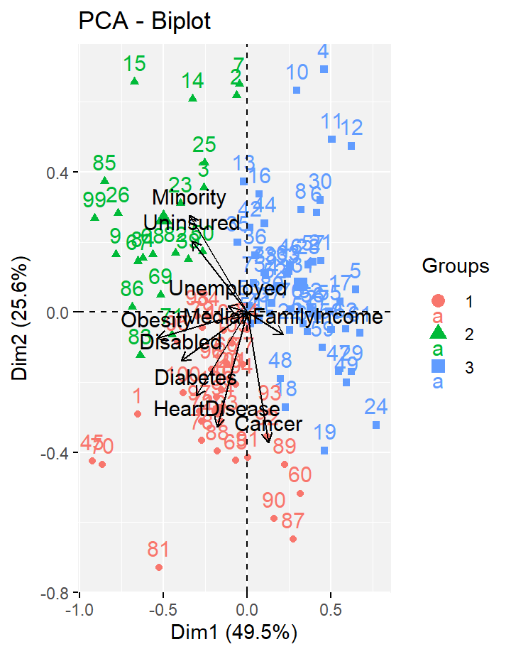

**Advisors:** Holly Rosson and David Abernathy.

**Student Researchers:** Gracen Alleman, Neylan Visnius, and Mason Hollar

### **Introduction**

Clustering is a data analysis technique that divides a dataset into distinct groups, with each group containing similar data points. We apply clustering to CDC social vulnerability and health conditions data to identify and map geographic regions in Western North Carolina that are most suitable for targeted outreach efforts by **Bounty and Soul:** a local food bank which provides access to fresh produce and wellness education for individuals in Buncombe, Henderson, and McDowell counties.

### **Data**

**CDC PLACES** data contains percent estimates of multiple health conditions for all census tracts across the United States. **Cancer, diabetes, obesity, and heart disease** were chosen to be part of our clustering algorithm because individuals with these diseases would likely benefit the most from dietary interventions from Bounty and Soul.

Similarly, **CDC’s Social Vulnerability Index** contains estimates of multiple social vulnerability variables for all census tracts across the United States. **Median family income, percent minority, unemployed, uninsured, and disabled** were also included in our clustering algorithm.

### **Methods**

- **R Studio** was used to clean, reorganize, and merge the datasets.
- 3 clusters were using the **k-means clustering algorithm**
- **Principle component analysis**, as well as basic descriptive statistics provided a characterization of the clusters
- QGIS was used to map the clusters.

### **References**

- CDC Social Vulnerability Index 2022, accessed December, 2024: https://www.atsdr.cdc.gov/place-health/php/svi/svi-data-documentation-download.html
- CDC PLACES 2024 for North Carolina, accessed December, 2024: https://www.cdc.gov/places/
- This research was supported by a **SEEDS grant** from the **South Big Data Innovation Hub**.

[figure not shown]

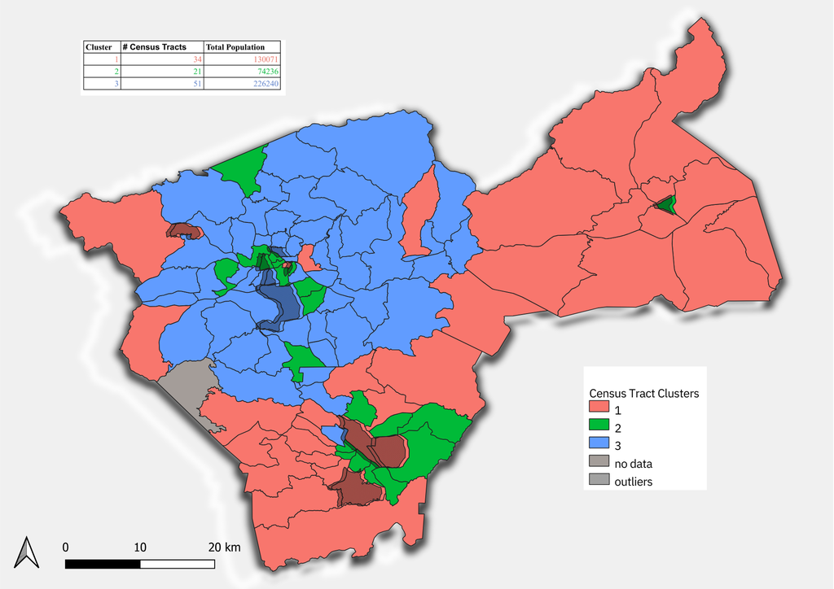

### **Results**

See the tabs on the right for visualizations of each of the conditions according to cluster. In summary:

The census tracts in **Cluster 1** have a wide range of median family incomes, has the highest cancer and heart disease rates, and medium social vulnerability variables.

Outliers in cluster 1 are very low income, higher cancer levels (Leicester, parts of Henderson).

The tracts in **Cluster 2** have the lowest income, highest social vulnerability variables, the highest rates of diabetes and obesity, and the lowest cancer rates.

**Cluster 3** consists of census tracts characterized by predominantly above-average income levels, as well as the lowest rates of diabetes, heart disease and obesity. Outliers in this cluster have lower income as well.

### **Health Conditions**

[interactive chart not shown]

### **Social Vulnerability**

[interactive chart not shown]

### **Median Family Income**

[interactive chart not shown]

### **Principle Component Analysis**

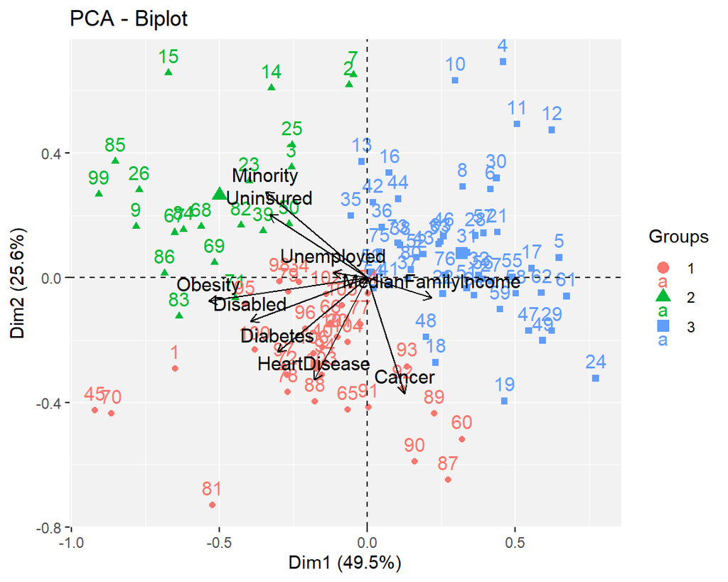

### **The Data**

|  | CountyName | CensusTract | Diabetes | Cancer | Obesity | HeartDisease | Unemployed | Uninsured | Disabled | Minority | MedianFamilyIncome | TotPop | Cluster |
| --- | --- | --- | --- | --- | --- | --- | --- | --- | --- | --- | --- | --- | --- |
| 1 | Buncombe | 37021000100 | 16.8 | 9.5 | 33.8 | 11.5 | 2.126044039483675 | 7.137433561123766 | 40.9 | 35.38344722854973 | 20455 | 1317 | 1 |
| 2 | Buncombe | 37021000200 | 9.7 | 5.8 | 30.3 | 5 | 0 | 15.16272189349112 | 27.2 | 36.24260355029586 | 54167 | 1352 | 2 |
| 3 | Buncombe | 37021000300 | 11 | 6.5 | 31.1 | 6.6 | 2.220360284876414 | 16.8412232928362 | 34.8 | 27.48219522413071 | 48235 | 2387 | 2 |
| 4 | Buncombe | 37021000400 | 5.6 | 4.6 | 23.1 | 3.8 | 4.864593781344032 | 7.79839518555667 | 28.3 | 19.13239719157473 | 58585 | 3988 | 3 |
| 5 | Buncombe | 37021000500 | 9.1 | 11.1 | 23.6 | 6.6 | 1.140994295028525 | 6.112469437652812 | 22.1 | 13.23010051616409 | 107009 | 3681 | 3 |
| 6 | Buncombe | 37021000600 | 8.8 | 7.1 | 27.2 | 5.5 | 1.815181518151815 | 7.755775577557755 | 24.1 | 7.425742574257425 | 61675 | 1818 | 3 |
| 7 | Buncombe | 37021000700 | 9.3 | 5.3 | 30.2 | 4.8 | 1.184990125082291 | 16.52402896642528 | 27.6 | 34.23304805793286 | 70109 | 1519 | 2 |
| 8 | Buncombe | 37021000800 | 9.5 | 8.4 | 26.9 | 6.1 | 1.649782923299566 | 2.402315484804631 | 25.2 | 31.43270622286541 | 86905 | 3455 | 3 |
| 9 | Buncombe | 37021000900 | 15.7 | 6.8 | 36.3 | 8.4 | 3.399528778189162 | 9.155166610568832 | 39.1 | 49.88219454729047 | 30653 | 2971 | 2 |
| 10 | Buncombe | 37021001000 | 7.1 | 5.6 | 27.8 | 4.1 | 2.463651050080775 | 13.5702746365105 | 24.2 | 19.97172859450727 | 72150 | 4952 | 3 |

[output cut: 96 more lines]